# Figure 1 Notebook: ScanLag

**Author: Evan Pepper-Tunick**

Last updated: Nov 19, 2025

This notebook is for analyzing the data generated in the ScanLag experiments using wildtype *M. smegmatis* mc2155. Also included is the analysis of the growth of the isolates chosen from the ScanLag experiment. ScanLag is a technology originally developed in the Balaban lab (10.1038/nmeth.1485) by Levin-Reisman et al. 2010.

ScanLag data read into this notebook has been modified to exclude erroneous colony assignments in the ScanLag image analysis, due to the image analysis and colony identification process occasionally assigning more (2+) or less (0) colonies as one individual colony.

The raw ScanLag data was generated using ScanLag_Analysis.ipynb

**Important note: to run notebook, user’s computer must have ≥ 2.0 GB memory**

```r
# importing necessary libraries
{
  library(ggplot2)
  library(ggridges)
  library(growthcurver)
  library(tidyverse)
  library(purrr)
  library(drc)
  library(knitr)
  library(factoextra)
  library(naniar)
  library(rstatix)
  library(ggpubr)
  library(scales)
}

# setting plot theme attributes
plot.theme <- theme(title = element_text(size = 14),
                    axis.text = element_text(size = 12),
                    axis.title = element_text(size = 12),
                    legend.title = element_text(size = 14),
                    legend.text = element_text(size = 10),
                    strip.text = element_text(size = 10))

# setting colors for each cluster of phenotypically distinct colonies
cluster.colors <- c('gray', '#F8766D', '#00BA38', '#619CFF')
treated.cluster.colors <- c('#F8766D', '#00BA38', '#619CFF')
```

```r
# reading in data from two independent experiments
sl.expt.1 <- read_csv(file = '../data/Fig1/scanlag-experiment-1.csv', col_types = cols())
sl.expt.2 <- read_csv(file = '../data/Fig1/scanlag-experiment-2.csv', col_types = cols())
sl.data <- rbind(sl.expt.1, sl.expt.2)
# data from first 4 hours of experiment is subject to substantial noise, removing data
# filtering out data not relevant for this analysis, retaining only INH treated and untreated data
sl.data.filtered <- sl.data %>% filter(time >= 4, experiment %in% c(NA, 'I'))
```

Next, we want to estimate the time of appearance (toa), growth rate (r), and final colony size (cs) for each colony

```r
# getting vector of unique colony names to iterate over
unique.colonies <- unique(sl.data.filtered$colony.label)
# empty list to store toa, r, cs for each colony
metric.list <- list()
plot.list <- list()
sampling.frequency <- 1e-2
for (i in 1:length(unique.colonies)) {
  # selecting the colony of interest from entire data
  growth.data <- sl.data.filtered %>% filter(colony.label == unique.colonies[i])
  # removing NAs from data
  growth.data <- growth.data[!is.na(growth.data %>% pull(colony.label)), ]
  # smoothing data with smooth.spline
  smooth <- smooth.spline(x = growth.data$time, y = growth.data$growth, spar = 0.6)
  # storing smoothed data in dataframe
  smooth.data <- tibble(time = smooth$x,
                        growth = growth.data$growth,
                        pred.growth = smooth$y)
  # fixing data by subtracting off minimum value from all measurements
  smooth.data <- smooth.data %>%
    mutate_at(vars(-matches('time')), function(x) x - min(smooth.data$pred.growth))
  # using the smooth spline function to predict growth over the time period
  prediction <- predict(object = smooth, x = data.frame(seq(0, (max(smooth.data$time)),
                                                            by = sampling.frequency)), deriv = 0)
  pred.table <- data.frame(x = prediction$x, y = prediction$y)
  names(pred.table) <- c('time', 'pred.growth')
  # getting first derivative data
  first.deriv.data <- predict(object = smooth, x = data.frame(seq(0, (max(smooth.data$time)),
                                                                  by = sampling.frequency)), deriv = 1)
  # getting max rate and time of max rate
  r <- max(first.deriv.data$y)
  cs <- max(prediction$y)
  # setting toa threshold to when first derivative is ≥ 0.2 the max growth rate
  deriv.threshold <- 0.2 * r
  # getting toa value
  toa <- ( ( min(which(first.deriv.data$y > deriv.threshold)) /
               as.numeric(rownames(tail(first.deriv.data$y, 1))) ) * max(smooth.data$time) ) - 4 #hours
  # saving growth rate, carrying capacity, and toa to tibble
  metrics <- tibble(colony.label = unique.colonies[i],
                    r = r,
                    cs = cs,
                    toa = toa)
  # calculating distance for plotting slope line of max rate
  run <- max(smooth.data$time) - (cs / r)
  metric.list[[i]] <- metrics

  # creating plot and saving it to list for inspection
  growth.curve <- ggplot(data = smooth.data, aes(x = time, y = growth)) +
    geom_point(size = 1, alpha = 0.3) +
    geom_line(aes(x = time, y = pred.growth)) +
    geom_point(x = toa, y = smooth.data[[which.min(abs(toa - smooth.data$time)), 'growth']],
               color = 'green4', shape = 4, size = 2, stroke = 2) +
    annotate("text", x = (toa - 8), y = (0.10 * max(smooth.data$pred.growth)),
             label = paste('toa: ', round(toa, digits = 1), ' hours', sep = ''), color = 'green4', size = 4) +
    geom_point(x = max(smooth.data$time), y = cs, color = 'blue', shape = 4, size = 2, stroke = 2) +
    annotate("text", x = (max(smooth.data$time) - 12), y = (0.95 * cs),
             label = paste('colony size:\n', format(cs, scientific = TRUE, digits = 3), ' pixels', sep = ''),
             color = 'blue', size = 4) +
    annotate("segment", x = run, xend = max(smooth.data$time), y = 0, yend = cs, color = 'red',
             linetype = 'dashed') +
    annotate("text", x = (run + 10), y = (0.2 * max(smooth.data$pred.growth)),
             label = paste('max rate:\n', round(r, digits = 2), sep = ''), color = 'red', size = 4) +
    ggtitle(paste('colony', unique.colonies[i], sep = ' ')) +
    xlab('time (hours)') + ylab('growth (pixels)') +
    theme_minimal() +
    plot.theme

  plot.list[[i]] <- growth.curve
}
# row binding all colony metrics
colony.metrics <- do.call(rbind, metric.list)
```

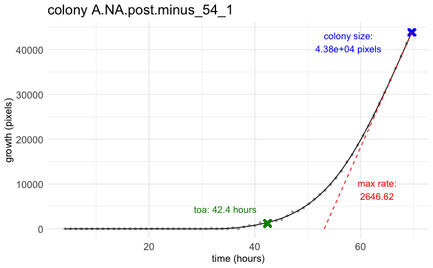

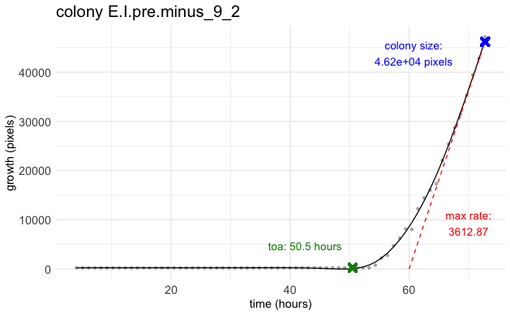

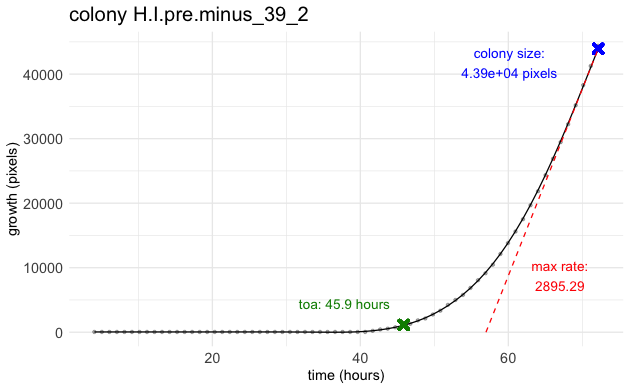

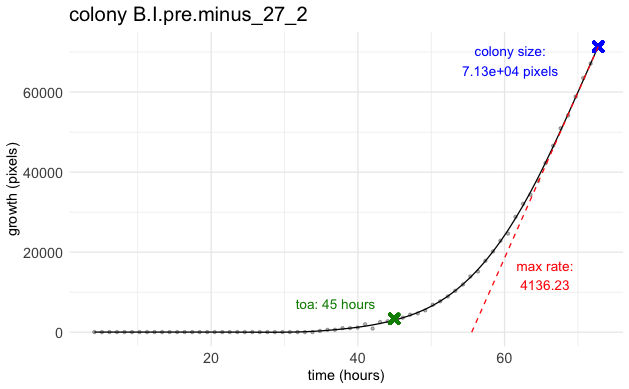

```r
# plotting some randomly selected colonies as a sanity check
colony.sample <- sample(c(1:length(unique.colonies)), size = 4, replace = F)
plot.list.sample <- list(plot.list[[colony.sample[1]]],
                         plot.list[[colony.sample[2]]],
                         plot.list[[colony.sample[3]]],
                         plot.list[[colony.sample[4]]])
# plotting sample data
walk(plot.list.sample, print)
```

Next, we want to use toa, r, and cs to cluster colonies based on their growth phenotype. This will be done using k-means clustering, with k = 3

```r
# resetting column names of data
colony.metrics$line <- unlist(lapply(strsplit(colony.metrics$colony.label, '[.]'), '[', 1))
colony.metrics$experiment <- unlist(lapply(strsplit(colony.metrics$colony.label, '[.]'), '[', 2))
colony.metrics$time.point <- unlist(lapply(strsplit(colony.metrics$colony.label, '[.]'), '[', 3))
colony.metrics$treatment <- unlist(lapply(strsplit(
  unlist(lapply(strsplit(colony.metrics$colony.label, '[.]'), '[', 4)), '_'), '[', 1))
# filtering data for clustering to only include treated samples on antibiotic plates
treated.data <- colony.metrics %>%
  filter(treatment == 'plus', time.point == 'post')
# also gathering untreated data
untreated.data <- colony.metrics %>%
  filter(treatment == 'minus')
# extracting data for clustering
cluster.data <- data.frame(treated.data) %>%
  dplyr::select(colony.label, r, cs, toa)
# setting rownames
rownames(cluster.data) <- cluster.data$colony.label
# retaining only metrics
cluster.data <- cluster.data[, 2:4]
# scale each variable to have a mean of 0 and sd of 1
cluster.data <- scale(cluster.data)
# make this example reproducible
set.seed(42)
# perform k-means clustering with k = 3 clusters
k = 3
km <- kmeans(cluster.data, centers = k, nstart = 25)
# clustering plot
cluster.plot <- fviz_cluster(km, data = cluster.data, geom = 'point', ggtheme = theme_minimal(),
                             main = '') + plot.theme
```

```r
# saving plot as pdf
pdf(file = '../figures/figure-panels/fig1-panel-a.pdf', height = 4, width = 6)
print(cluster.plot)
dev.off()
```

**Figure 1 Panel A**

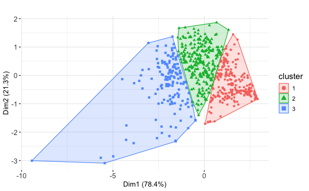

```r
cluster.plot
```

```r
# adding cluster assignment back to colony metric data for treated samples
treated.data$Cluster <- as.character(km$cluster)
# adding colony assignment of 0 to untreated data
untreated.data$Cluster <- 'Untreated'
# merging all data with cluster assignments together
clusters <- rbind(treated.data, untreated.data)
# swapping cluster 1 with cluster 3, and vice versa (cluster 1 should be early growers)
clusters <- clusters %>% mutate(Cluster = case_when(Cluster == '1' ~ '3',
                                                    Cluster == '3' ~ '1',
                                                    Cluster == '2' ~ '2',
                                                    Cluster == 'Untreated' ~ 'Untreated'))
# factorizing cluster assignment
clusters$Cluster <- factor(clusters$Cluster, levels = c('Untreated', '1', '2', '3'))
clusters$colony <- as.numeric(unlist(lapply(strsplit(clusters$colony.label, '_'), '[', 2)))
clusters$strain <- paste(clusters$line, '_', clusters$treatment, '_', clusters$colony, sep = '')
```

Optional write to file

```r
write_csv(clusters, file = '../data/Fig1/colony-cluster-assignments.csv')
```

```r
# adding cluster information back to growth data to plot growth curves
growth <- sl.data.filtered
growth <- merge(growth, clusters[, c(1, 9)])
# getting means of each cluster and plotting
growth.modified <- growth
growth.modified$time <- round(growth.modified$time, digits = 0)
# finding times where not all data is available and removing them
underrepresented.times <- growth.modified %>%
  group_by(time) %>% tally() %>% filter(n < nrow(clusters)) %>% pull(time)
growth.modified <- growth.modified %>% filter(!time %in% underrepresented.times)
growth.means <- growth.modified %>%
  group_by(time, Cluster) %>%
  summarise(mean.growth = mean(growth), stdev = sd(growth))

growth.curves <- ggplot(data = growth.modified,
                        aes(x = time, y = growth, group = colony.label, color = Cluster)) +
  geom_line(alpha = 0.04) +
  geom_line(data = growth.means,
            aes(x = time, y = mean.growth, group = Cluster, color = Cluster), linewidth = 1.5) +
  ylim(0, 50000) +
  xlab('Time (hours)') + ylab('Growth (pixels)') +
  scale_color_manual(values = cluster.colors) +
  theme_minimal() +
  plot.theme
```

```r
# generating plot
pdf(file = '../figures/figure-panels/fig1-panel-b.pdf', height = 4, width = 4)
print(growth.curves)
dev.off()
```

**Figure 1 Panel B**

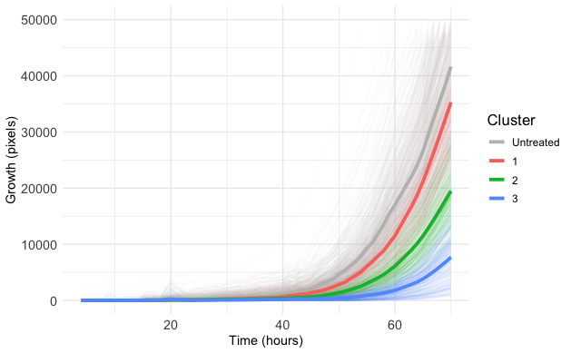

```r
growth.curves
```

```r
# looking only at the time of appearance of each cluster
toa.plot <- ggplot(data = clusters, aes(x = Cluster, y = toa, fill = Cluster, group = Cluster)) +
  geom_violin(trim = F, alpha = 0.7) +
  geom_boxplot(width = 0.05, fill = 'white') +
  ylab('Time of appearance (hours)') + xlab('Cluster') +
  ggtitle('') +
  scale_fill_manual(values = cluster.colors) +
  theme_minimal() +
  theme(legend.position = "none") +
  plot.theme
```

```r
# generating plot
pdf(file = '../figures/figure-panels/fig1-panel-c.pdf', height = 4, width = 4)
print(toa.plot)
dev.off()
```

**Figure 1 Panel C**

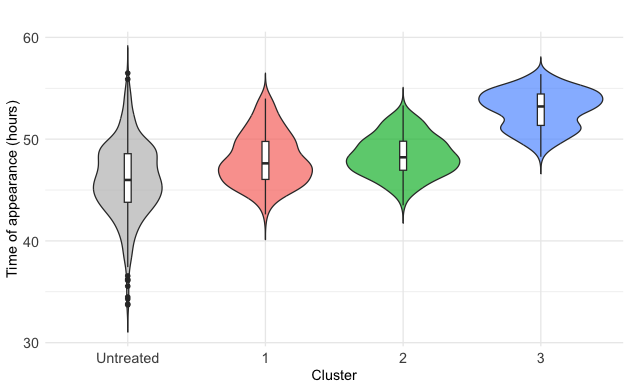

```r
toa.plot
```

Next, after picking representative colonies from each of the clusters and phenotyping them with a dose response assay, we’re able to calculate both fitness (uninhibited growth WRT wildtype) and INH IC50

**Important note: assay 1 only had the final OD measured after ~60 hours due to a power outage**

```r
# reading in each dataset from each dose response assay
kinetic.data <- read_csv(file = '../data/Fig1/dose-response-assay-1.csv',
                         name_repair = 'minimal', col_types = cols())
kinetic.data.long <- kinetic.data %>% pivot_longer(cols = everything(), names_to = 'sample', values_to = 'od')
# getting blank data averages
blank.data.avg <- mean(kinetic.data.long %>% filter(sample == 'blank') %>% pull(od))
sample.data <- kinetic.data.long %>% filter(sample != 'blank')
# subtracting off the blank from all sample ODs
sample.data$od <- sample.data$od - blank.data.avg
# splitting sample names into corresponding data
sample.data$line <- unlist(lapply(strsplit(sample.data$sample, '_'), '[', 1))
sample.data$abx <- unlist(lapply(strsplit(sample.data$sample, '_'), '[', 2))
sample.data$background <- unlist(lapply(strsplit(sample.data$sample, '_'), '[', 3))
sample.data$colony <- as.numeric(unlist(lapply(strsplit(sample.data$sample, '_'), '[', 4)))
sample.data$concentration <- as.numeric(unlist(lapply(strsplit(sample.data$sample, '_'), '[', 5)))
sample.data$rep <- unlist(lapply(strsplit(sample.data$sample, '_'), '[', 6))
sample.data$isolate <- paste(
  sample.data$line, '_', sample.data$background, '_', sample.data$colony, '_', sample.data$rep, sep = '')
sample.data <- sample.data %>%
  dplyr::select(line, abx, background, colony, concentration, rep, od, isolate, sample)
```

The next step is to calculate the relative fitness and INH IC50

```r
unique.samples <- unique(sample.data$isolate)
sampling.freq <- 1e-2
concentration.range <- seq(sampling.freq, (max(sample.data$concentration) * 2), by = sampling.freq)

rg.tables.list <- list()
isolate.metrics.list <- list()
suppressWarnings(for (s in 1:length(unique.samples)) {
  selected.data <- sample.data %>% filter(isolate == unique.samples[s])
  # getting relative growth at each concentration relative to the uninhibited growth
  selected.data$relative.growth <- selected.data$od / selected.data$od[1]
  # save rg data to list
  rg.tables.list[[s]] <- selected.data
  # writing logic to catch data that doesn't reach 50% relative growth (ie. very resistant)
  # using a higher cutoff since log models still get fit properly even with > 85% growth at highest concentration
  if (tail(selected.data$relative.growth, n = 1) >= 0.85) {
    inferred.ic50 <- max(concentration.range)
  }
  else {
    # fitting a log model
    log.model <- drm(relative.growth ~ concentration, data = selected.data, fct = LL.4(fixed = c(NA, 0, 1, NA)))
    pred.growth <- predict(object = log.model, newdata = data.frame(concentration.range))
    pred.table <- data.frame(x = concentration.range, y = pred.growth)
    # extracting IC50 value
    inferred.ic50 <- pred.table$x[which.min(abs(pred.table$y - 0.50))]

    if (inferred.ic50 == sampling.freq) {
      inferred.ic50 <- max(concentration.range)
    }
    else {
      inferred.ic50 <- inferred.ic50
    }
  }
  # relative fitness is uninhibited growth vs average untreated control growth from all lines
  avg.line.wt.od <- mean(sample.data %>%
                           filter(background == 'minus', concentration == 0) %>% pull(od))
  relative.fitness <- selected.data$od[1] / avg.line.wt.od
  # saving ic50 value and relative fitness for each sample
  isolate.metrics.list[[s]] <- tibble(isolate = unique.samples[s],
                                      ic50 = inferred.ic50,
                                      fitness = relative.fitness,
                                      assay = 1)
})
isolate.metrics.1 <- do.call(rbind, isolate.metrics.list)
```

**The following dose response assays were run as intended, so area under the growth curve (AUC) will be used**

```r
# first creating function for converting time from hours:minutes:seconds to just hours
# function for converting time
convert.time <- function(time.vector) {
  new.out <- c()
  for(x in time.vector)
  {
    temporal.vector <- strsplit(x,split = ":")[[1]]
    new.out <- c(new.out, as.numeric(temporal.vector[1]) + ((as.numeric(temporal.vector[3]) +
                                                               (60*as.numeric(temporal.vector[2])))/3600))
  }
  new.out <- round(new.out, digits = 3)
  new.out
}
```

```r
assays <- c('2', '3', '4', '5', '6', '7')
group.metrics <- list()

for (a in 1:length(assays)) {
  kinetic.data <- read_csv(file = paste('../data/Fig1/dose-response-assay-', assays[a], '.csv', sep = ''),
                           name_repair = 'minimal', col_types = cols())
  # converting time units
  kinetic.data$Time <- convert.time(as.character(kinetic.data$Time))
  # getting blank data averages, removing any contaminated outliers
  blanks <- startsWith(names(kinetic.data), prefix = 'blank')
  blank.data <- cbind(kinetic.data$Time, kinetic.data[, blanks, drop = FALSE])
  blank.data[, 2:ncol(blank.data)] <- replace_with_na_all(blank.data[, 2:ncol(blank.data)],
                                                          condition = ~.x > 0.10)
  names(blank.data)[1] <- 'time'
  blank.avg <- rowMeans(blank.data[, c(2:ncol(blank.data))], na.rm = T)
  # reformatting growth data to be more easily plot-able and usable
  samples <- !startsWith(names(kinetic.data), prefix = 'blank')
  expt.data <- cbind(kinetic.data[, samples, drop = FALSE])
  names(expt.data) <- c('time', names(expt.data[2:ncol(expt.data)]))
  # subtracting off blanks
  expt.data[2:ncol(expt.data)] <- expt.data[2:ncol(expt.data)] - blank.avg
  # using the growth curver library to estimate growth curve parameters, including AUC (auc_e)
  # removing all data after 48 hours, as this is about when WT untreated reaches stationary
  sample.data <- SummarizeGrowthByPlate(plate = expt.data %>% filter(time <= 48))
  # splitting sample names into corresponding data
  sample.data$line <- unlist(lapply(strsplit(sample.data$sample, '_'), '[', 1))
  sample.data$abx <- unlist(lapply(strsplit(sample.data$sample, '_'), '[', 2))
  sample.data$background <- unlist(lapply(strsplit(sample.data$sample, '_'), '[', 3))
  sample.data$colony <- as.numeric(unlist(lapply(strsplit(sample.data$sample, '_'), '[', 4)))
  sample.data$concentration <- as.numeric(unlist(lapply(strsplit(sample.data$sample, '_'), '[', 5)))
  sample.data$rep <- unlist(lapply(strsplit(sample.data$sample, '_'), '[', 6))
  sample.data$isolate <- paste(
    sample.data$line, '_', sample.data$background, '_', sample.data$colony, '_', sample.data$rep, sep = '')
  sample.data <- sample.data %>%
    dplyr::select(line, abx, background, colony, concentration, rep, auc_e, isolate, sample)

  # The next step is to calculate the relative fitness and INH IC50
  unique.samples <- unique(sample.data$isolate)
  sampling.freq <- 1e-2
  concentration.range <- seq(sampling.freq, (max(sample.data$concentration) * 2), by = sampling.freq)

  rg.tables.list <- list()
  isolate.metrics.list <- list()
  suppressWarnings(for (s in 1:length(unique.samples)) {
    selected.data <- sample.data %>% filter(isolate == unique.samples[s])
    # getting relative growth at each concentration relative to the uninhibited growth
    selected.data$relative.growth <- selected.data$auc_e / selected.data$auc_e[1]
    # save rg data to list
    rg.tables.list[[s]] <- selected.data
    # writing logic to catch data that doesn't reach ≤ 85% relative growth (ie. very resistant)
    if (tail(selected.data$relative.growth, n = 1) >= 0.85) {
      inferred.ic50 <- max(concentration.range)
    }
    else {
      # fitting a log model
      log.model <- drm(relative.growth ~ concentration, data = selected.data,
                       fct = LL.4(fixed = c(NA, 0, 1, NA)))
      pred.growth <- predict(object = log.model, newdata = data.frame(concentration.range))
      pred.table <- data.frame(x = concentration.range, y = pred.growth)
      # extracting IC50 value
      inferred.ic50 <- pred.table$x[which.min(abs(pred.table$y - 0.50))]

      if (inferred.ic50 == sampling.freq) {
        inferred.ic50 <- max(concentration.range)
      }
      else {
        inferred.ic50 <- inferred.ic50
      }
    }
    # relative fitness is uninhibited growth vs average control growth from all lines
    avg.line.wt.auc <- mean(sample.data %>%
                              filter(background == 'minus', concentration == 0) %>% pull(auc_e))
    relative.fitness <- selected.data$auc_e[1] / avg.line.wt.auc
    # saving ic50 value and relative fitness for each sample
    isolate.metrics.list[[s]] <- tibble(isolate = unique.samples[s],
                                        ic50 = inferred.ic50,
                                        fitness = relative.fitness,
                                        assay = as.numeric(assays[a]))
  })
  group.metrics[[a]] <- do.call(rbind, isolate.metrics.list)
}
isolate.metrics.2 <- do.call(rbind, group.metrics)
```

```r
# joining all dose response assay data to get IC50 fold change and log2 fold change
isolate.metrics <- rbind(isolate.metrics.1, isolate.metrics.2)
# resplitting isolate name into corresponding data
isolate.metrics$line <- unlist(lapply(strsplit(isolate.metrics$isolate, '_'), '[', 1))
isolate.metrics$background <- unlist(lapply(strsplit(isolate.metrics$isolate, '_'), '[', 2))
isolate.metrics$colony <- as.numeric(unlist(lapply(strsplit(isolate.metrics$isolate, '_'), '[', 3)))
isolate.metrics$rep <- unlist(lapply(strsplit(isolate.metrics$isolate, '_'), '[', 4))
isolate.metrics$sample <- paste(isolate.metrics$isolate, '_', isolate.metrics$assay, sep = '')
isolate.metrics <- isolate.metrics %>%
  dplyr::select(line, background, colony, rep, isolate, sample, assay, ic50, fitness)
# iterating over every sample to get ic50 fold change WRT the untreated controls
unique.samples <- unique(isolate.metrics$sample)
relative.ic50.sample.data <- list()
for (s in 1:length(unique.samples)) {
  sample.ic50 <- isolate.metrics %>% filter(sample == unique.samples[s]) %>% pull(ic50)
  sample.line <- isolate.metrics %>% filter(sample == unique.samples[s]) %>% pull(line)
  sample.assay <- isolate.metrics %>% filter(sample == unique.samples[s]) %>% pull(assay)
  avg.wt.ic50 <- mean(isolate.metrics %>%
                        filter(line == sample.line, assay == sample.assay, background == 'minus') %>% pull(ic50))
  # calculating ic50 fold change and ic50 log2 fold change
  relative.ic50.sample.data[[s]] <- tibble(sample = unique.samples[s],
                                           ic50.fc = sample.ic50 / avg.wt.ic50,
                                           ic50.log2.fc = log2(sample.ic50 / avg.wt.ic50))
}
relative.ic50.data <- do.call(rbind, relative.ic50.sample.data)
# rejoining with the rest of the isolate data
isolate.metrics <- full_join(isolate.metrics, relative.ic50.data)
# now calculating averages for each strain
isolate.metrics$strain <- paste(
  isolate.metrics$line, '_', isolate.metrics$background, '_', isolate.metrics$colony, sep = '')
strain.avgs <- isolate.metrics %>% group_by(strain) %>%
  summarise(avg.ic50 = mean(ic50),
            avg.ic50.fc = mean(ic50.fc), sd.ic50.fc = sd(ic50.fc), se.ic50.fc = (sd(ic50.fc) / 2),
            avg.ic50.log2.fc = mean(ic50.log2.fc), sd.ic50.log2.fc = sd(ic50.log2.fc),
            avg.fitness = mean(fitness), sd.fitness = sd(fitness), se.fitness = (sd(fitness) / 2))
```

```r
# reassigning the cluster information to be able to group by cluster or color by cluster
full.data <- left_join(strain.avgs, clusters)
# removing duplicated data from joining
full.data <- full.data[!duplicated(full.data$strain), ]
```

```r
# next, grouping by cluster and plotting the ic50 log2 fold change and fitness as boxplots
full.data.treated <- full.data %>% filter(Cluster != 'Untreated')
full.data.treated$Cluster <- factor(full.data.treated$Cluster, levels = c(1, 2, 3))
# performing t tests to identify any significant differences between the grouped cluster phenotypes
ic50.stat.test <- full.data.treated %>%
  pairwise_t_test(avg.ic50.fc ~ Cluster, paired = F, p.adjust.method = "bonferroni")
ic50.stat.test <- ic50.stat.test %>% add_xy_position(x = 'Cluster')

fitness.stat.test <- full.data.treated %>%
  pairwise_t_test(avg.fitness ~ Cluster, paired = F, p.adjust.method = "bonferroni")
fitness.stat.test <- fitness.stat.test %>% add_xy_position(x = 'Cluster')

# generating ic50 log2 fold change boxplots with stats
ic50.by.cluster <- ggboxplot(full.data.treated, x = 'Cluster', y = 'avg.ic50.fc',
          fill = 'Cluster', add = 'jitter',
          add.params = list(width = 0.2, shape = 21, size = 2, alpha = 0.7)) +
  stat_pvalue_manual(ic50.stat.test, label = 'p.adj.signif', tip.length = 0.02,
                     step.increase = 0.005 / (max(full.data.treated$avg.ic50.fc) -
                                                min(full.data.treated$avg.ic50.fc))) +
  xlab('Cluster') + ylab('INH IC50 fold change\nWRT untreated controls') +
  scale_fill_manual(values = treated.cluster.colors) +
  theme_minimal() +
  plot.theme +
  theme(legend.position = 'none')
```

```r
# generating plot
pdf(file = '../figures/figure-panels/fig1-panel-d.pdf', height = 4, width = 3)
ic50.by.cluster
dev.off()
```

```r
# generating fitness boxplots with stats
fitness.by.cluster <- ggboxplot(full.data.treated, x = 'Cluster', y = 'avg.fitness',
          fill = 'Cluster', add = 'jitter',
          add.params = list(width = 0.2, shape = 21, size = 2, alpha = 0.7)) +
  stat_pvalue_manual(fitness.stat.test, label = 'p.adj.signif', tip.length = 0.02,
                     step.increase = 0.015 / (max(full.data.treated$avg.fitness) -
                                                min(full.data.treated$avg.fitness))) +
  xlab('Cluster') + ylab('Relative fitness\nWRT untreated controls') +
  scale_fill_manual(values = treated.cluster.colors) +
  theme_minimal() +
  plot.theme +
  theme(legend.position = 'none')
```

```r
# generating plot
pdf(file = '../figures/figure-panels/fig1-panel-e.pdf', height = 4, width = 3)
fitness.by.cluster
dev.off()
```

**Figure 1 Panel D and E**

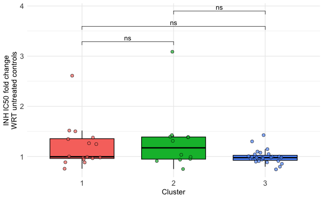

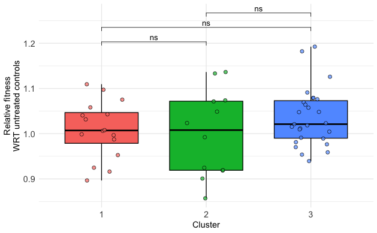

```r
walk(list(ic50.by.cluster, fitness.by.cluster), print)
```

```r
# getting standard error of all wildtype strains ic50 and fitness
se.wt.ic50.fc <- sd(full.data %>% filter(treatment == 'minus') %>% pull(avg.ic50.fc)) / 2
se.wt.fitness <- sd(full.data %>% filter(treatment == 'minus') %>% pull(avg.fitness)) / 2
# for Mtb, INH drug resistance is defined as an MIC ≥ 0.4 µg/mL
# Mtb H37Rv has an INH MIC of ~0.06 µg/mL
# we are defining INH resistance as an equivalent fold change increase in IC50 in Msm
resistance.fc <- 0.4 / 0.06
resistance.log2.fc <- log2(0.4 / 0.06)
# generating plot of ic50 log2 fold change vs relative fitness
resistance.fitness.plot <- ggplot(
  full.data %>% filter(treatment == 'plus'), aes(x = avg.ic50.fc, y = avg.fitness, fill = Cluster)) +
  annotate('rect', xmin = 1 - se.wt.ic50.fc, xmax = 1 + se.wt.ic50.fc,
           ymin = 1 - se.wt.fitness, ymax = 1 + se.wt.fitness, alpha = 1, fill = 'gray') +
  geom_point(size = 2, shape = 21, alpha = 0.6) +
  geom_errorbar(aes(ymin = avg.fitness - se.fitness, ymax = avg.fitness + se.fitness,
                    color = Cluster), width = 0.025, alpha = 0.3) +
  geom_errorbar(aes(xmin = avg.ic50.fc - se.ic50.fc, xmax = avg.ic50.fc + se.ic50.fc,
                    color = Cluster), width = 0.01, alpha = 0.3) +
  xlab(bquote(Isoniazid~IC[50]~fold~change~WRT~untreated~controls)) +
  ylab('Relative fitness\nWRT untreated controls') +
  scale_fill_manual(values = treated.cluster.colors) +
  theme_minimal() +
  plot.theme +
  theme(legend.position = 'none')
```

```r
# generating plot
pdf(file = '../figures/figure-panels/fig1-panel-f.pdf', height = 4, width = 8)
print(resistance.fitness.plot)
dev.off()
```

**Figure 1 Panel F**

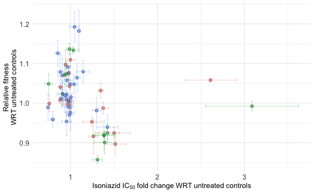

```r
resistance.fitness.plot
```

```r
# performing t tests to check for significant increase in ic50 amongst treated isolates
wt.data <- isolate.metrics %>% filter(background == 'minus')
wt.ic50s <- wt.data %>% pull(ic50)
treated.isolates <- full.data %>% filter(treatment == 'plus') %>% pull(strain)
n.treated.isolates <- length(treated.isolates)
llr.treated.isolates <- full.data %>% filter(treatment == 'plus', avg.ic50.fc >= 1.1) %>% pull(strain)
n.llr.treated.isolates <- length(llr.treated.isolates)

ic50.t.test.results <- list()
for (i in 1:length(llr.treated.isolates)) {
  isolate.data <- isolate.metrics %>% filter(strain == llr.treated.isolates[i])
  isolate.ic50s <- isolate.data %>% pull(ic50)
  isolate.t.test <- t.test(isolate.ic50s, wt.ic50s, alternative = 'two.sided', var.equal = FALSE)
  ic50.t.test.results[[i]] <- tibble(isolate = llr.treated.isolates[i],
                                t.test.p.value = isolate.t.test$p.value)
}

significant.llrs <- do.call(rbind, ic50.t.test.results)
significant.llrs$adj.pvalue <- p.adjust(significant.llrs$t.test.p.value, method = 'fdr')
n.significant.llrs <- nrow(significant.llrs %>% filter(adj.pvalue <= 0.05))

# performing t tests to check for significant increase in fitness amongst treated isolates
wt.fitness <- wt.data %>% pull(fitness)
fit.treated.isolates <- full.data %>% filter(treatment == 'plus', avg.fitness >= 1.1) %>% pull(strain)
n.fit.treated.isolates <- length(fit.treated.isolates)

fitness.t.test.results <- list()
for (f in 1:length(fit.treated.isolates)) {
  isolate.data <- isolate.metrics %>% filter(strain == fit.treated.isolates[f])
  isolate.fitness <- isolate.data %>% pull(fitness)
  isolate.t.test <- t.test(isolate.fitness, wt.fitness, alternative = 'two.sided', var.equal = FALSE)
  fitness.t.test.results[[f]] <- tibble(isolate = fit.treated.isolates[f],
                                t.test.p.value = isolate.t.test$p.value)
}

significant.fits <- do.call(rbind, fitness.t.test.results)
significant.fits$adj.pvalue <- p.adjust(significant.fits$t.test.p.value, method = 'fdr')
n.significant.fits <- nrow(significant.fits %>% filter(adj.pvalue <= 0.05))
```

```r
# extracting data from all isolates corresponding to the mutant strains identified after sequencing
mutant.strains <- tibble(strain = c('G_plus_8', 'G_plus_16', 'B_plus_12', 'H_plus_4', 'H_plus_8', 'B_plus_103'),
                         mutation = c('ohrR P4* fs', 'ohrR P4* fs', 'mfs1 G105D',
                                      'ntaA_5 E50* fs', 'ntaA_5 E50* fs', 'fas1 E177G'))
mutant.strain.data <- left_join(mutant.strains, full.data)
# optional write out for data
# write_csv(mutant.strain.data, file = '../data/Fig1/mutant-strain-phenotypes.csv')
```

Next, mutants *ohrR P4- fs*, *mfs1 G105D*, and *ntaA_5 E50- fs* were subjected to INH tolerance assay

```r
# first reading in spotting assay data containing colony counts
dt.data.wide <- read_csv(file = '../data/Fig1/time-kill-colony-counts.csv',
                         name_repair = 'minimal', col_types = cols())
####################################################################################
dt.data.long <- dt.data.wide %>%
  pivot_longer(cols = -c(1, 2), names_to = 'isolate.info', values_to = 'colonies')
# splitting up information for each sample
isolate.info <- strsplit(dt.data.long$isolate.info, '-')
# resetting tibble with all data
dt.data <- tibble(isolate = unlist(lapply(isolate.info, '[', 1)),
                  bio.rep = unlist(lapply(isolate.info, '[', 2)),
                  tech.rep = as.numeric(unlist(lapply(isolate.info, '[', 3))),
                  time.point = as.numeric(unlist(lapply(isolate.info, '[', 4))),
                  dilution = as.numeric(dt.data.long$dilution),
                  dilution.factor = as.numeric(dt.data.long$dilution.factor),
                  colonies = dt.data.long$colonies)
# remove NAs representing rows with too many or too few colonies
dt.data <- na.omit(dt.data)
# calculating cfus per ml
dt.data$cfus.per.ml <- (dt.data$colonies / dt.data$dilution.factor) * (1000 / 4) # 4 µl spotted
# summarising and getting averages across replicates
dt.data.avg <- dt.data %>% group_by(isolate, bio.rep, tech.rep, time.point) %>%
  summarise(avg.cfus.per.ml = mean(cfus.per.ml), sd.cfus = sd(cfus.per.ml))
dt.data.avg$sample <- paste(dt.data.avg$isolate, '-', dt.data.avg$bio.rep, '-', dt.data.avg$tech.rep, sep = '')

# getting percent survival for each isolate relative to t0 for that isolate
isolates <- unique(dt.data.avg$sample)
survival.per.isolate <- list()
for (i in 1:length(isolates)) {
  sample.id.list <- list()
  percent.survival.list <- list()
  # for each isolate...
  isolate.data <- dt.data.avg %>% filter(sample == isolates[i])
  t0.data <- isolate.data %>% filter(time.point == 0)
  time.sample.list <- list()
  times <- c(0, 6, 24, 30, 48, 72)
  for (j in 1:length(times)) {
    time.sample.list[j] <- times[j]
    sample.id.list[j] <- isolates[i]
    if (times[j] %in% unique(isolate.data$time.point)) {
      percent.survival <- ( dt.data.avg %>%
                              filter(time.point == times[j], sample == isolates[i]) %>%
                              pull(avg.cfus.per.ml) / t0.data %>%
                              pull(avg.cfus.per.ml) ) * 100
    }
    else {
      percent.survival <- NA
    }
    percent.survival.list[j] <- percent.survival
  }
  survival.per.isolate[[i]] <- tibble(sample = unlist(sample.id.list),
                                      time.point = unlist(time.sample.list),
                                      percent.survival = unlist(percent.survival.list))
}
# binding all survival data back together
percent.survival.table <- do.call('rbind', survival.per.isolate)
# factorizing and re-leveling data based on sample ID
percent.survival.table$isolate <- unlist(lapply(strsplit(percent.survival.table$sample, '-'), '[', 1))
percent.survival.table$isolate <- as.factor(percent.survival.table$isolate)
# getting average values
percent.survival.table.avg <- percent.survival.table %>% group_by(isolate, time.point) %>%
  summarise(avg.percent.survival = mean(percent.survival),
            sd.percent.survival = sd(percent.survival),
            mad.percent.survival = mad(percent.survival)) %>%
  ungroup()
# optional write out to file
write_csv(percent.survival.table, file = '../data/Fig1/inh-tolerance-final-data.csv')
# sub-setting data to only contain mutant data
all.mutants <- percent.survival.table %>% filter(isolate %in% c('ohrR', 'mfs1', 'ntaA'))
all.mutants$isolate <- factor(all.mutants$isolate, levels = c('ohrR', 'mfs1', 'ntaA'))
avg.mutants <- percent.survival.table.avg %>% filter(isolate %in% c('ohrR', 'mfs1', 'ntaA'))
avg.mutants$isolate <- factor(avg.mutants$isolate, levels = c('ohrR', 'mfs1', 'ntaA'))

# creating time kill curves
kill.curves <- ggplot(all.mutants, aes(x = time.point, y = percent.survival)) +
  geom_line(aes(group = sample, color = isolate), alpha = 0.25, linetype = 'dashed') +
  geom_line(data = percent.survival.table %>%
              filter(isolate == 'wt') %>%
              select(-isolate), aes(x = time.point, y = percent.survival, group = sample),
            color = 'blue', alpha = 0.15, linetype = 'dashed') +
  geom_line(data = avg.mutants, aes(x = time.point, y = avg.percent.survival, color = isolate), linewidth = 2) +
  geom_point(data = avg.mutants, aes(x = time.point, y = avg.percent.survival, color = isolate), size = 3.5) +
  geom_line(data = percent.survival.table.avg %>% filter(isolate == 'wt') %>%
              select(-isolate), aes(x = time.point, y = avg.percent.survival), color = 'blue', linewidth = 2) +
  geom_point(data = percent.survival.table.avg %>% filter(isolate == 'wt') %>%
               select(-isolate), aes(x = time.point, y = avg.percent.survival), color = 'blue', size = 3.5) +
  geom_hline(yintercept = 1, linetype = 'dashed') +
  scale_color_manual(values = c('red', 'gold2', 'green3')) +
  xlab('Time point (hours)') + ylab('Survival (%)') +
  facet_wrap(~isolate) +
  scale_y_log10(breaks = trans_breaks('log10', function(x) 10^x),
                labels = trans_format('log10', math_format(10^.x))) +
  theme_minimal() +
  plot.theme + theme(legend.position = 'none')

pdf(file = '../figures/figure-panels/fig1-panel-g.pdf', height = 5, width = 14)
print(kill.curves)
dev.off()
```

**Figure 1 Panel G**

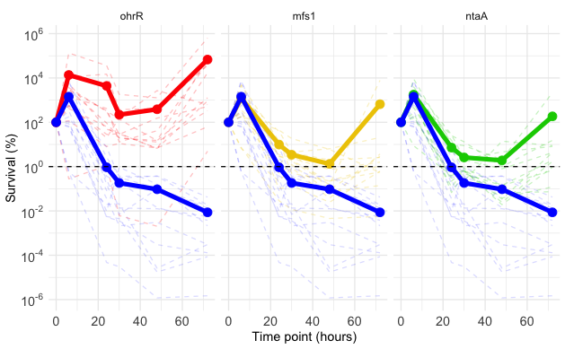

```r
kill.curves
```